# SF_01_GRANT_RECORD_MAINT_X

Maintains records to substantiate grants and other assistance, eligibility, and selection criteria [x] · Checkbox report

## Overview

**Description**

For grantmakers, does the organizationmaintain records on their grants and processes?

**Table**

`SF-P01-T00-FRGN-ACTS` (one)

**Location code**

`SCHED-F-PART-01-LINE-01`

**Family**

`SCHED-F-PART-01-LINE-01`

**Data type**

checkbox (xsd: , BooleanType)

**Scope**

PC

**Status**

unreviewed

3

xpaths mapped (2 observed)

114,478

filings with a value

2009–2024

tax years observed

2

open flags (1 errors)

## Flags

| Severity | Flag | Xpath | Detail |
| --- | --- | --- | --- |
| ⚠ error | `POLARITY` | IRS990ScheduleF/Form990ScheduleFPartI/NoRecipientOver5K | negated element ‘NoRecipientOver5K’ pooled with non-negated xpaths |
| ⓘ info | `UNOBSERVED` | IRS990ScheduleF/Form990ScheduleFPartI/NoRecipientOver5K | never observed in TY2009-2024 filings |

## Xpaths

All mapped xpaths (under /Return/ReturnData or /Return/ReturnHeader), oldest first. Charts label each series by its xpath.

| Xpath | Form | First year | Last year | Versions | Filings | Repeats in |
| --- | --- | --- | --- | --- | --- | --- |
| IRS990ScheduleF/GrantRecordsMaintained | Sched F | 2009 | 2012 | 17 | 12,858 | 0.0% |
| IRS990ScheduleF/GrantRecordsMaintainedInd | Sched F | 2013 | 2024 | 37 | 101,620 | 0.0% |
| IRS990ScheduleF/Form990ScheduleFPartI/NoRecipientOver5K | Sched F |  |  |  | 0 |  |

## Coverage

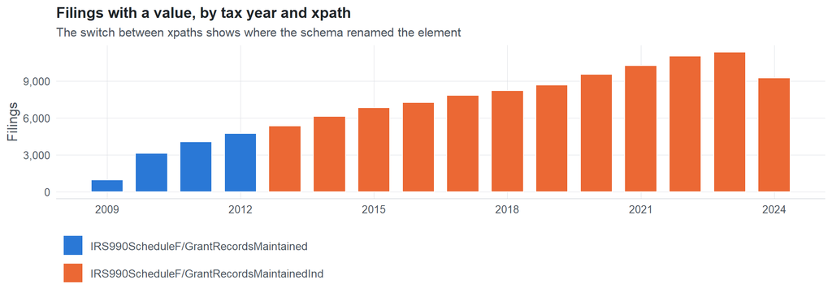

**Table view**

Table view: filings by tax year and series

| Tax year | IRS990ScheduleF/GrantRecordsMaintained | IRS990ScheduleF/GrantRecordsMaintainedInd |
| --- | --- | --- |
| 2009 | 947 | 0 |
| 2010 | 3,133 | 0 |
| 2011 | 4,060 | 0 |
| 2012 | 4,718 | 0 |
| 2013 | 0 | 5,347 |
| 2014 | 0 | 6,124 |
| 2015 | 0 | 6,812 |
| 2016 | 0 | 7,250 |
| 2017 | 0 | 7,835 |
| 2018 | 0 | 8,205 |
| 2019 | 0 | 8,669 |
| 2020 | 0 | 9,548 |
| 2021 | 0 | 10,239 |
| 2022 | 0 | 11,028 |
| 2023 | 0 | 11,329 |
| 2024 | 0 | 9,234 |

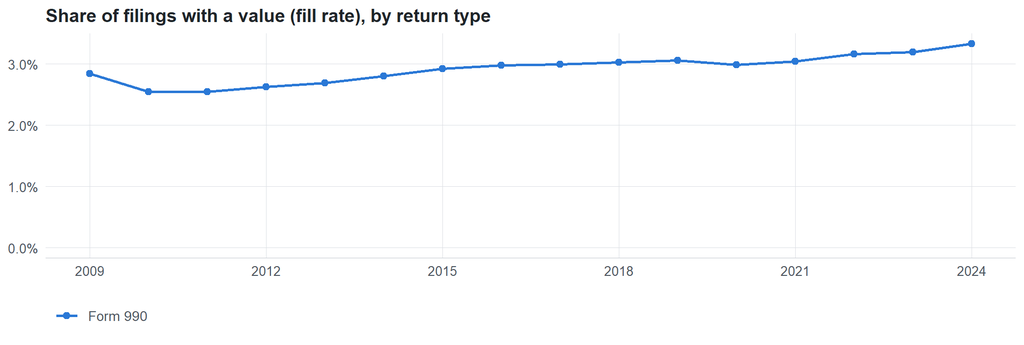

**Table view**

Table view: fill rate

[output not shown]

## Values

| Result | Check | Detail |
| --- | --- | --- |
| ✓ pass | Values are checkbox codes | 100.0% of values are X / true / false / 1 / 0 |
| ⓘ info | Meaning of a blank | 27% of values are explicit false/0, so a missing value is not the same as unchecked |
| ⚠ fail | Element names agree in polarity | negated: NoRecipientOver5K \| not negated: GrantRecordsMaintained, GrantRecordsMaintainedInd |

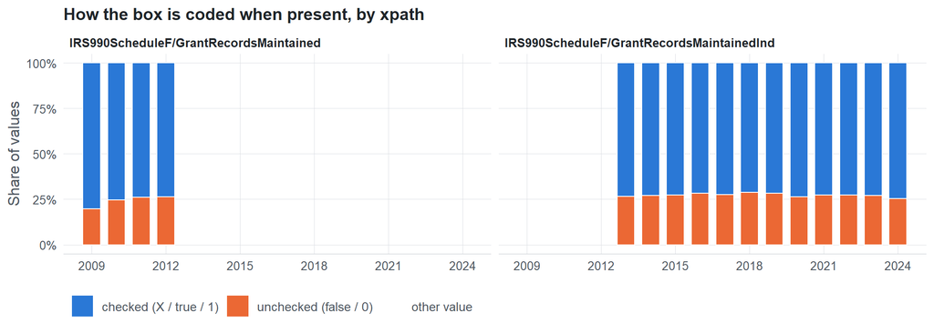

**Table view**

Table view: value coding by tax year

| Series | Tax year | Code | Filings | Share |
| --- | --- | --- | --- | --- |
| IRS990ScheduleF/GrantRecordsMaintained | 2009 | checked (X / true / 1) | 761 | 80.4% |
| IRS990ScheduleF/GrantRecordsMaintained | 2009 | unchecked (false / 0) | 186 | 19.6% |
| IRS990ScheduleF/GrantRecordsMaintained | 2010 | checked (X / true / 1) | 2,362 | 75.4% |
| IRS990ScheduleF/GrantRecordsMaintained | 2010 | unchecked (false / 0) | 771 | 24.6% |
| IRS990ScheduleF/GrantRecordsMaintained | 2011 | checked (X / true / 1) | 3,003 | 74.0% |
| IRS990ScheduleF/GrantRecordsMaintained | 2011 | unchecked (false / 0) | 1,057 | 26.0% |
| IRS990ScheduleF/GrantRecordsMaintained | 2012 | checked (X / true / 1) | 3,472 | 73.6% |
| IRS990ScheduleF/GrantRecordsMaintained | 2012 | unchecked (false / 0) | 1,246 | 26.4% |
| IRS990ScheduleF/GrantRecordsMaintainedInd | 2013 | checked (X / true / 1) | 3,927 | 73.4% |
| IRS990ScheduleF/GrantRecordsMaintainedInd | 2013 | unchecked (false / 0) | 1,420 | 26.6% |
| IRS990ScheduleF/GrantRecordsMaintainedInd | 2014 | checked (X / true / 1) | 4,468 | 73.0% |
| IRS990ScheduleF/GrantRecordsMaintainedInd | 2014 | unchecked (false / 0) | 1,656 | 27.0% |
| IRS990ScheduleF/GrantRecordsMaintainedInd | 2015 | checked (X / true / 1) | 4,948 | 72.6% |
| IRS990ScheduleF/GrantRecordsMaintainedInd | 2015 | unchecked (false / 0) | 1,864 | 27.4% |
| IRS990ScheduleF/GrantRecordsMaintainedInd | 2016 | checked (X / true / 1) | 5,195 | 71.7% |
| IRS990ScheduleF/GrantRecordsMaintainedInd | 2016 | unchecked (false / 0) | 2,055 | 28.3% |
| IRS990ScheduleF/GrantRecordsMaintainedInd | 2017 | checked (X / true / 1) | 5,677 | 72.5% |
| IRS990ScheduleF/GrantRecordsMaintainedInd | 2017 | unchecked (false / 0) | 2,158 | 27.5% |
| IRS990ScheduleF/GrantRecordsMaintainedInd | 2018 | checked (X / true / 1) | 5,848 | 71.3% |
| IRS990ScheduleF/GrantRecordsMaintainedInd | 2018 | unchecked (false / 0) | 2,357 | 28.7% |
| IRS990ScheduleF/GrantRecordsMaintainedInd | 2019 | checked (X / true / 1) | 6,215 | 71.7% |
| IRS990ScheduleF/GrantRecordsMaintainedInd | 2019 | unchecked (false / 0) | 2,454 | 28.3% |
| IRS990ScheduleF/GrantRecordsMaintainedInd | 2020 | checked (X / true / 1) | 7,034 | 73.7% |
| IRS990ScheduleF/GrantRecordsMaintainedInd | 2020 | unchecked (false / 0) | 2,514 | 26.3% |
| IRS990ScheduleF/GrantRecordsMaintainedInd | 2021 | checked (X / true / 1) | 7,454 | 72.8% |
| IRS990ScheduleF/GrantRecordsMaintainedInd | 2021 | unchecked (false / 0) | 2,785 | 27.2% |
| IRS990ScheduleF/GrantRecordsMaintainedInd | 2022 | checked (X / true / 1) | 8,010 | 72.6% |
| IRS990ScheduleF/GrantRecordsMaintainedInd | 2022 | unchecked (false / 0) | 3,018 | 27.4% |
| IRS990ScheduleF/GrantRecordsMaintainedInd | 2023 | checked (X / true / 1) | 8,275 | 73.0% |
| IRS990ScheduleF/GrantRecordsMaintainedInd | 2023 | unchecked (false / 0) | 3,054 | 27.0% |
| IRS990ScheduleF/GrantRecordsMaintainedInd | 2024 | checked (X / true / 1) | 6,883 | 74.5% |
| IRS990ScheduleF/GrantRecordsMaintainedInd | 2024 | unchecked (false / 0) | 2,351 | 25.5% |

Raw values by xpath (all years)

| Series | Value | Filings |
| --- | --- | --- |
| IRS990ScheduleF/GrantRecordsMaintained | true | 4,824 |
| IRS990ScheduleF/GrantRecordsMaintained | 1 | 4,774 |
| IRS990ScheduleF/GrantRecordsMaintained | 0 | 2,122 |
| IRS990ScheduleF/GrantRecordsMaintained | false | 1,138 |
| IRS990ScheduleF/GrantRecordsMaintainedInd | true | 39,228 |
| IRS990ScheduleF/GrantRecordsMaintainedInd | 1 | 34,706 |
| IRS990ScheduleF/GrantRecordsMaintainedInd | 0 | 16,294 |
| IRS990ScheduleF/GrantRecordsMaintainedInd | false | 11,392 |

## Examples

| Tax year | Return | Xpath | Organization | Value | Source |
| --- | --- | --- | --- | --- | --- |
| 2024 | 990 | IRS990ScheduleF/GrantRecordsMaintainedInd | THE AMERICAN HUMANIST ASSOCIATION | 1 | [XML](https://gt990datalake-rawdata.s3.amazonaws.com/EfileData/XmlFiles/202503179349309825_public.xml) |
| 2023 | 990 | IRS990ScheduleF/GrantRecordsMaintainedInd | RINGLING COLLEGE OF ART AND DESIGN INC | 1 | [XML](https://gt990datalake-rawdata.s3.amazonaws.com/EfileData/XmlFiles/202501049349302265_public.xml) |
| 2022 | 990 | IRS990ScheduleF/GrantRecordsMaintainedInd | HOPE FOR HAITI CHILDREN’S CENTER | false | [XML](https://gt990datalake-rawdata.s3.amazonaws.com/EfileData/XmlFiles/202343199349331649_public.xml) |
| 2021 | 990 | IRS990ScheduleF/GrantRecordsMaintainedInd | AFRICA NETWORK FOR ANIMAL WELFARE- USA | true | [XML](https://gt990datalake-rawdata.s3.amazonaws.com/EfileData/XmlFiles/202222209349300402_public.xml) |
| 2020 | 990 | IRS990ScheduleF/GrantRecordsMaintainedInd | HOPE FOR TOMORROW INC | 1 | [XML](https://gt990datalake-rawdata.s3.amazonaws.com/EfileData/XmlFiles/202143199349304499_public.xml) |
| 2019 | 990 | IRS990ScheduleF/GrantRecordsMaintainedInd | Northwestern University | true | [XML](https://gt990datalake-rawdata.s3.amazonaws.com/EfileData/XmlFiles/202141959349301014_public.xml) |
| 2018 | 990 | IRS990ScheduleF/GrantRecordsMaintainedInd | Crossroads Global Village (US) Limited | true | [XML](https://gt990datalake-rawdata.s3.amazonaws.com/EfileData/XmlFiles/201912959349300101_public.xml) |
| 2017 | 990 | IRS990ScheduleF/GrantRecordsMaintainedInd | AMERICAS SOCIETY INC | 1 | [XML](https://gt990datalake-rawdata.s3.amazonaws.com/EfileData/XmlFiles/201823199349310107_public.xml) |
| 2016 | 990 | IRS990ScheduleF/GrantRecordsMaintainedInd | LAFAYETTE COLLEGE | 1 | [XML](https://gt990datalake-rawdata.s3.amazonaws.com/EfileData/XmlFiles/201811359349307786_public.xml) |
| 2015 | 990 | IRS990ScheduleF/GrantRecordsMaintainedInd | THE UNIVERSITY OF QUEENSLAND IN AMERICA | 1 | [XML](https://gt990datalake-rawdata.s3.amazonaws.com/EfileData/XmlFiles/201622109349300832_public.xml) |
| 2014 | 990 | IRS990ScheduleF/GrantRecordsMaintainedInd | UNITED WAY OF GREATER ATLANTA INC | 1 | [XML](https://gt990datalake-rawdata.s3.amazonaws.com/EfileData/XmlFiles/201621339349302307_public.xml) |
| 2013 | 990 | IRS990ScheduleF/GrantRecordsMaintainedInd | Plan International USA Inc | true | [XML](https://gt990datalake-rawdata.s3.amazonaws.com/EfileData/XmlFiles/201520439349300207_public.xml) |

## Reviewer checklist

- The definition matches the form line and instructions for every xpath’s schema years.
- Every xpath pooled here measures the same thing on the 990 and 990-EZ (close enough for analysis).
- The coverage chart has no unexplained gaps or jumps between tax years.
- Each open flag is fixed, or accepted with a note in validation_log.csv.
- The box means the same thing (and the same polarity) under every xpath: ‘required’ is never pooled with ‘not required’.
- Absent means unchecked for this line, or the question was skipped; the data dictionary says which.
- Yes/No questions coded as two separate boxes are mapped to one variable only when that is intended.

Record the review as a row in `inst/extdata/src/validation_log.csv` (variable_name, reviewer, date, status, note). Evidence built 2026-09-23 17:09:04 MST from the ef2 DuckDB builds (tax years 2009–2024).